# SongPopularity.Rmd

### Robust estimator

```r
coeftest(final_reg, vcov = hccm)
```

```
##
## t test of coefficients:
##
##                 Estimate Std. Error t value  Pr(>|t|)
## (Intercept)    71.311235   3.098273 23.0164 < 2.2e-16 ***
## bpm            -0.025956   0.014758 -1.7587  0.079034 .
## nrgy           -0.039661   0.020174 -1.9660  0.049675 *
## dnce            0.131274   0.026580  4.9388 9.718e-07 ***
## log(live)      -1.065252   0.418610 -2.5447  0.011138 *
## log(acous + 1)  0.675156   0.231248  2.9196  0.003611 **
## pop             1.658473   0.755385  2.1955  0.028435 *
## rock            5.046528   1.974092  2.5564  0.010775 *
## hip_hop         2.828620   0.960792  2.9441  0.003341 **
## rap             2.716213   1.383669  1.9631  0.050014 .
## ---
## Signif. codes:  0 '***' 0.001 '**' 0.01 '*' 0.05 '.' 0.1 ' ' 1
```

### Functional form misspecifications

```r
reset(final_reg, vcov = hccm)
```

```
##
##  RESET test
##
## data:  final_reg
## RESET = 4.3829, df1 = 2, df2 = 741, p-value = 0.01282
```

To address this issue, let’s try to add some new variables to the model:

### Interactions

```r
final_reg = lm(popularity ~ bpm + nrgy + dnce + log(live) + log(acous + 1) + pop + rock + hip_hop + rap + I(bpm * rock), data = songs)

coeftest(final_reg, vcov = hccm)
```

```
##
## t test of coefficients:
##
##                 Estimate Std. Error t value  Pr(>|t|)
## (Intercept)    71.576112   3.098589 23.0996 < 2.2e-16 ***
## bpm            -0.029408   0.014914 -1.9719  0.048997 *
## nrgy           -0.038075   0.020263 -1.8790  0.060631 .
## dnce            0.131475   0.026597  4.9432 9.512e-07 ***
## log(live)      -1.067054   0.419850 -2.5415  0.011240 *
## log(acous + 1)  0.683126   0.231850  2.9464  0.003316 **
## pop             1.656078   0.755525  2.1920  0.028693 *
## rock           -9.583382   9.799308 -0.9780  0.328411
## hip_hop         2.823963   0.961565  2.9368  0.003419 **
## rap             2.752302   1.385796  1.9861  0.047393 *
## I(bpm * rock)   0.129561   0.089444  1.4485  0.147896
## ---
## Signif. codes:  0 '***' 0.001 '**' 0.01 '*' 0.05 '.' 0.1 ' ' 1
```

```r
final_reg = lm(popularity ~ bpm + nrgy + dnce + log(live) + log(acous + 1) + pop + rock + hip_hop + rap + I(log(live) * rock), data = songs)

coeftest(final_reg, vcov = hccm)
```

```
##
## t test of coefficients:
##
##                      Estimate Std. Error t value  Pr(>|t|)
## (Intercept)         71.285649   3.078678 23.1546 < 2.2e-16 ***
## bpm                 -0.026161   0.014732 -1.7759  0.076167 .
## nrgy                -0.041551   0.020135 -2.0636  0.039404 *
## dnce                 0.128615   0.026557  4.8429 1.559e-06 ***
## log(live)           -0.900101   0.424085 -2.1225  0.034131 *
## log(acous + 1)       0.643988   0.231605  2.7806  0.005565 **
## pop                  1.646617   0.755708  2.1789  0.029653 *
## rock                20.848937   6.707411  3.1083  0.001953 **
## hip_hop              2.808331   0.961310  2.9214  0.003591 **
## rap                  2.717524   1.380170  1.9690  0.049328 *
## I(log(live) * rock) -5.791669   2.305859 -2.5117  0.012226 *
## ---
## Signif. codes:  0 '***' 0.001 '**' 0.01 '*' 0.05 '.' 0.1 ' ' 1
```

```r
final_reg = lm(popularity ~ bpm + nrgy + dnce + log(live) + log(acous + 1) + pop + rock + hip_hop + rap + I(log(live) * rap), data = songs)

coeftest(final_reg, vcov = hccm)
```

```
##
## t test of coefficients:
##
##                     Estimate Std. Error t value  Pr(>|t|)
## (Intercept)        71.694782   3.096255 23.1553 < 2.2e-16 ***
## bpm                -0.026727   0.014663 -1.8228  0.068735 .
## nrgy               -0.040343   0.020141 -2.0031  0.045531 *
## dnce                0.132492   0.026701  4.9621 8.661e-07 ***
## log(live)          -1.194345   0.425617 -2.8062  0.005145 **
## log(acous + 1)      0.677339   0.230925  2.9332  0.003459 **
## pop                 1.665132   0.755173  2.2050  0.027763 *
## rock                5.080086   1.966878  2.5828  0.009991 **
## hip_hop             2.831922   0.960944  2.9470  0.003309 **
## rap                -6.380061   5.691028 -1.1211  0.262620
## I(log(live) * rap)  3.516043   2.172039  1.6188  0.105922
## ---
## Signif. codes:  0 '***' 0.001 '**' 0.01 '*' 0.05 '.' 0.1 ' ' 1
```

### Exponents

```r
final_reg = lm(popularity ~ bpm + nrgy + dnce + log(live) + log(acous + 1) + pop + rock + hip_hop + rap + I(dnce^2), data = songs)

coeftest(final_reg, vcov = hccm)
```

```
##
## t test of coefficients:
##
##                  Estimate Std. Error t value  Pr(>|t|)
## (Intercept)    51.3380052  7.3599443  6.9753 6.777e-12 ***
## bpm            -0.0204386  0.0146172 -1.3983 0.1624548
## nrgy           -0.0556384  0.0193182 -2.8801 0.0040902 **
## dnce            0.7896523  0.2162224  3.6520 0.0002785 ***
## log(live)      -1.0577120  0.4176971 -2.5322 0.0115391 *
## log(acous + 1)  0.6347101  0.2284538  2.7783 0.0056031 **
## pop             1.5268303  0.7520201  2.0303 0.0426827 *
## rock            5.0317474  1.9381755  2.5961 0.0096152 **
## hip_hop         3.2709483  0.9672121  3.3818 0.0007579 ***
## rap             3.0465935  1.3201073  2.3078 0.0212831 *
## I(dnce^2)      -0.0050775  0.0015781 -3.2176 0.0013492 **
## ---
## Signif. codes:  0 '***' 0.001 '**' 0.01 '*' 0.05 '.' 0.1 ' ' 1
```

```r
final_reg = lm(popularity ~ bpm + nrgy + dnce + log(live) + log(acous + 1) + pop + rock + hip_hop + rap + I(dnce^2) + I(nrgy^2), data = songs)

coeftest(final_reg, vcov = hccm)
```

```
##
## t test of coefficients:
##
##                   Estimate  Std. Error t value  Pr(>|t|)
## (Intercept)    52.93588213  7.91818537  6.6854 4.542e-11 ***
## bpm            -0.02070140  0.01472053 -1.4063 0.1600569
## nrgy           -0.11037942  0.10512289 -1.0500 0.2940597
## dnce            0.79113812  0.21770802  3.6339 0.0002985 ***
## log(live)      -1.05285135  0.41808083 -2.5183 0.0120026 *
## log(acous + 1)  0.62326751  0.22870708  2.7252 0.0065787 **
## pop             1.52762238  0.75428002  2.0253 0.0431984 *
## rock            5.02059247  1.94780157  2.5776 0.0101425 *
## hip_hop         3.25064325  0.96696930  3.3617 0.0008145 ***
## rap             3.06143456  1.32816625  2.3050 0.0214423 *
## I(dnce^2)      -0.00507890  0.00158731 -3.1997 0.0014346 **
## I(nrgy^2)       0.00042413  0.00082507  0.5141 0.6073667
## ---
## Signif. codes:  0 '***' 0.001 '**' 0.01 '*' 0.05 '.' 0.1 ' ' 1
```

#### Multiple functions together

```r
final_reg = lm(popularity ~ bpm + nrgy + dnce + log(live) + log(acous + 1) + pop + rock + hip_hop + rap + I(log(live) * rock) + I(bpm * rock) + I(log(live) * rap) + I(dnce^2), data = songs)

coeftest(final_reg, vcov = hccm)
```

```
##
## t test of coefficients:
##
##                       Estimate Std. Error t value  Pr(>|t|)
## (Intercept)         52.7639365  7.3320560  7.1963 1.526e-12 ***
## bpm                 -0.0247520  0.0146904 -1.6849 0.0924287 .
## nrgy                -0.0558487  0.0193208 -2.8906 0.0039582 **
## dnce                 0.7596378  0.2155941  3.5235 0.0004522 ***
## log(live)           -1.0149561  0.4327341 -2.3454 0.0192684 *
## log(acous + 1)       0.6162400  0.2291509  2.6892 0.0073236 **
## pop                  1.5248767  0.7521533  2.0273 0.0429862 *
## rock                 6.4317439 10.2676851  0.6264 0.5312424
## hip_hop              3.2309397  0.9682309  3.3370 0.0008895 ***
## rap                 -4.8079641  5.2566591 -0.9146 0.3606784
## I(log(live) * rock) -5.4890434  2.9657699 -1.8508 0.0645985 .
## I(bpm * rock)        0.1204973  0.0896563  1.3440 0.1793647
## I(log(live) * rap)   3.0439534  1.9731669  1.5427 0.1233391
## I(dnce^2)           -0.0048559  0.0015738 -3.0855 0.0021085 **
## ---
## Signif. codes:  0 '***' 0.001 '**' 0.01 '*' 0.05 '.' 0.1 ' ' 1
```

Let’s try without log(*live*) **rap*

```r
final_reg = lm(popularity ~ bpm + nrgy + dnce + log(live) + log(acous + 1) + pop + rock + hip_hop + rap + I(log(live) * rock) + I(bpm * rock) + I(dnce^2), data = songs)

coeftest(final_reg, vcov = hccm)
```

```
##
## t test of coefficients:
##
##                       Estimate Std. Error t value  Pr(>|t|)
## (Intercept)         52.1616787  7.3046727  7.1409 2.226e-12 ***
## bpm                 -0.0239919  0.0147633 -1.6251 0.1045671
## nrgy                -0.0555222  0.0193844 -2.8643 0.0042983 **
## dnce                 0.7673572  0.2148180  3.5721 0.0003771 ***
## log(live)           -0.8996228  0.4234171 -2.1247 0.0339457 *
## log(acous + 1)       0.6131014  0.2294746  2.6718 0.0077118 **
## pop                  1.5171134  0.7524571  2.0162 0.0441396 *
## rock                 6.8307510 10.2582413  0.6659 0.5056963
## hip_hop              3.2336204  0.9679929  3.3405 0.0008782 ***
## rap                  3.0711979  1.3199985  2.3267 0.0202528 *
## I(log(live) * rock) -5.6103910  2.9648132 -1.8923 0.0588388 .
## I(bpm * rock)        0.1196368  0.0896465  1.3345 0.1824386
## I(dnce^2)           -0.0049240  0.0015675 -3.1412 0.0017496 **
## ---
## Signif. codes:  0 '***' 0.001 '**' 0.01 '*' 0.05 '.' 0.1 ' ' 1
```

Better, but what if *bpm***rock* is removed?

```r
final_reg = lm(popularity ~ bpm + nrgy + dnce + log(live) + log(acous + 1) + pop + rock + hip_hop + rap + I(log(live) * rock) + I(dnce^2), data = songs)

coeftest(final_reg, vcov = hccm)
```

```
##
## t test of coefficients:
##
##                       Estimate Std. Error t value  Pr(>|t|)
## (Intercept)         51.5950071  7.3023825  7.0655 3.705e-12 ***
## bpm                 -0.0207127  0.0145841 -1.4202 0.1559641
## nrgy                -0.0572218  0.0193004 -2.9648 0.0031263 **
## dnce                 0.7778307  0.2147082  3.6227 0.0003115 ***
## log(live)           -0.8998246  0.4234278 -2.1251 0.0339098 *
## log(acous + 1)       0.6054636  0.2290000  2.6439 0.0083684 **
## pop                  1.5173429  0.7523269  2.0169 0.0440706 *
## rock                20.1495744  6.9065135  2.9175 0.0036358 **
## hip_hop              3.2453046  0.9675664  3.3541 0.0008369 ***
## rap                  3.0431908  1.3177975  2.3093 0.0212018 *
## I(log(live) * rock) -5.5406899  2.3858553 -2.3223 0.0204872 *
## I(dnce^2)           -0.0050059  0.0015667 -3.1952 0.0014569 **
## ---
## Signif. codes:  0 '***' 0.001 '**' 0.01 '*' 0.05 '.' 0.1 ' ' 1
```

It looks like the best model until now. However, *bpm* has become insignificant for the model. What happens if it is removed?

```r
final_reg = lm(popularity ~ nrgy + dnce + log(live) + log(acous + 1) + pop + rock + hip_hop + rap + I(log(live) * rock) + I(dnce^2), data = songs)

coeftest(final_reg, vcov = hccm)
```

```
##
## t test of coefficients:
##
##                       Estimate Std. Error t value  Pr(>|t|)
## (Intercept)         48.5285627  7.2651010  6.6797 4.706e-11 ***
## nrgy                -0.0615115  0.0191560 -3.2111 0.0013795 **
## dnce                 0.8066169  0.2140829  3.7678 0.0001778 ***
## log(live)           -0.9117318  0.4246370 -2.1471 0.0321108 *
## log(acous + 1)       0.6416060  0.2295817  2.7947 0.0053297 **
## pop                  1.5417249  0.7508648  2.0533 0.0403978 *
## rock                20.1762292  6.9278234  2.9123 0.0036952 **
## hip_hop              3.3324448  0.9630884  3.4602 0.0005708 ***
## rap                  2.8894521  1.3013618  2.2203 0.0266986 *
## I(log(live) * rock) -5.5019893  2.4132893 -2.2799 0.0228990 *
## I(dnce^2)           -0.0052252  0.0015616 -3.3462 0.0008608 ***
## ---
## Signif. codes:  0 '***' 0.001 '**' 0.01 '*' 0.05 '.' 0.1 ' ' 1
```

To get the R-squared:

```r
summary(final_reg)
```

```
##
## Call:
## lm(formula = popularity ~ nrgy + dnce + log(live) + log(acous +
##     1) + pop + rock + hip_hop + rap + I(log(live) * rock) + I(dnce^2),
##     data = songs)
##
## Residuals:
##      Min       1Q   Median       3Q      Max
## -20.4714  -4.9684   0.3376   5.0961  24.7105
##
## Coefficients:
##                      Estimate Std. Error t value Pr(>|t|)
## (Intercept)         48.528563   5.465677   8.879  < 2e-16 ***
## nrgy                -0.061512   0.019407  -3.170 0.001590 **
## dnce                 0.806617   0.164908   4.891 1.23e-06 ***
## log(live)           -0.911732   0.426071  -2.140 0.032693 *
## log(acous + 1)       0.641606   0.229209   2.799 0.005256 **
## pop                  1.541725   0.694830   2.219 0.026799 *
## rock                20.176229   7.014949   2.876 0.004141 **
## hip_hop              3.332445   1.000308   3.331 0.000907 ***
## rap                  2.889452   1.323103   2.184 0.029287 *
## I(log(live) * rock) -5.501989   2.495775  -2.205 0.027795 *
## I(dnce^2)           -0.005225   0.001259  -4.149 3.73e-05 ***
## ---
## Signif. codes:  0 '***' 0.001 '**' 0.01 '*' 0.05 '.' 0.1 ' ' 1
##
## Residual standard error: 7.301 on 740 degrees of freedom
## Multiple R-squared:  0.1408, Adjusted R-squared:  0.1292
## F-statistic: 12.13 on 10 and 740 DF,  p-value: < 2.2e-16
```

```r
reset(final_reg, vcov = hccm)
```

```
##
##  RESET test
##
## data:  final_reg
## RESET = 1.0987, df1 = 2, df2 = 740, p-value = 0.3338
```

After including two functions, the p-value of RESET test becomes not significant at a 5% level. This means that we do not reject the null hypothesis, therefore there is not a functional form misspecification anymore.

With this final model in mind it now possible to make conclusions about the analysis.

### Conclusions

A table summarizing the impacts of each variable on the target can be found below.

[output not shown]

Both the estimates of *dnce* and *dnce^2* are significant at a 1% level, hence there is evidence that songs that easier to dance tend to become more popular.

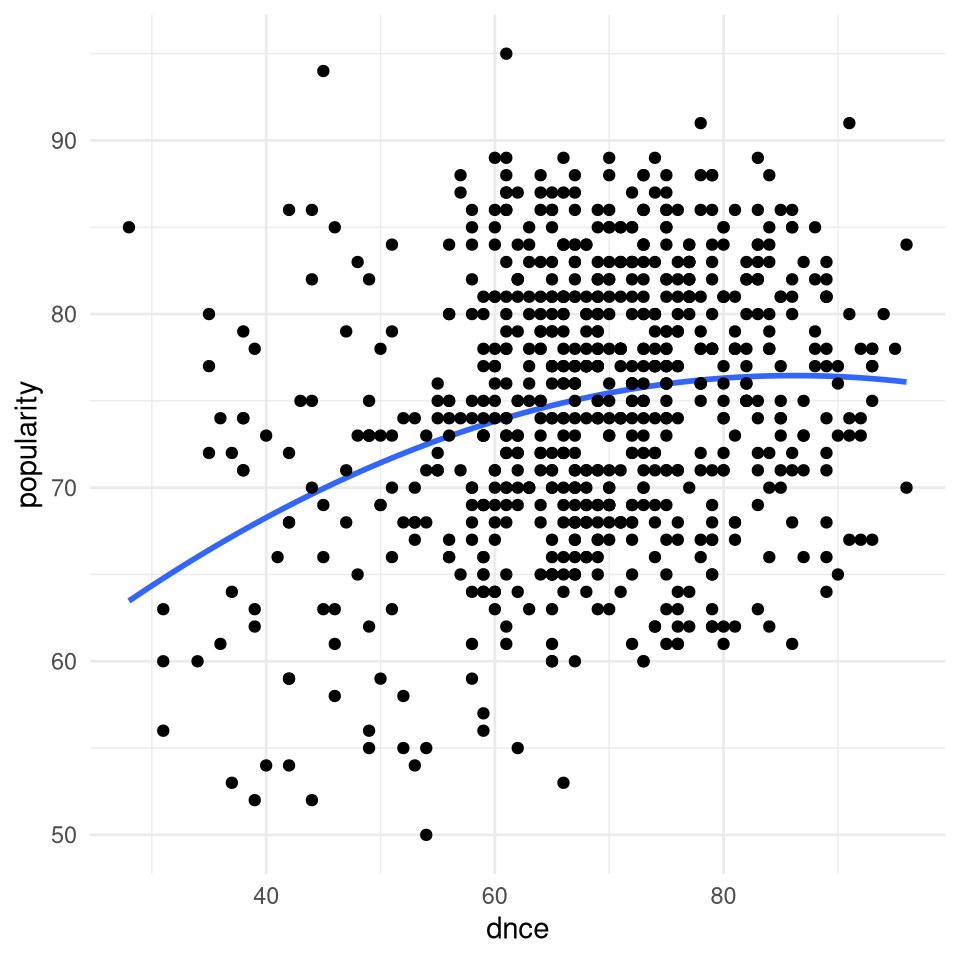

```r
ggplot(songs, aes(x=dnce, y=popularity)) + geom_smooth(method = 'lm', formula = y ~ x + I(x^2),  se=FALSE) + geom_point() + theme_minimal()
```

Project developed by: Inês Magessi r20220590